# Per-patient discovery of combinatorial cell-surface targets in prostate cancer

AND-gate and NOT-gate marker pairs from single-cell data, benchmarked against PSMA-PSCA

Author

William Guesdon

Published

2026-07-14 00:12

Abstract

Single-antigen therapies against solid tumors are limited by on-target off-tumor toxicity, because few surface antigens are truly absent from all healthy tissue. Combinatorial (logic-gated) targeting requires two conditions before a cell is engaged, which can recover specificity. We scan a curated cell-surface panel in single-cell data for pairs that discriminate prostate cancer cells from healthy human cell types, under AND (both markers on the tumor) and NOT (an activator spared by a blocker on healthy cells) logic. Pairs are scored per patient and summarized across patients, so no high cell-count patient drives a result. The preclinically validated PSMA-PSCA balanced-signalling pair is recovered as a positive control: each marker alone carries a large extra-prostatic transcript liability, and the AND gate collapses it. We report a Pareto frontier of surface-accessible pairs with higher per-patient malignant co-detection than PSMA-PSCA at comparable predicted normal-tissue liability. The leading pair, PSMA x STEAP1, is already in phase 1 as an OR-like dual antibody-drug conjugate, so the contribution is the AND framing rather than the pair; and cross-cohort replication shows its coverage is confined to AR+ adenocarcinoma and largely lost in castration-resistant, metastatic and neuroendocrine disease. These are transcript-level, hypothesis-generating rankings, not evidence of therapeutic safety.

# 1 Background

A major challenge for antigen-directed therapies in solid tumors is achieving tumor coverage without clinically important on-target, off-tumor activity. A single tumor antigen is rarely absent from every healthy tissue, so single-target CAR-T, T-cell engagers, and antibody-drug conjugates carry this risk. Combinatorial, logic-gated targeting requires two conditions before a cell is engaged and can recover the missing specificity (Kloss et al. 2013; Roybal et al. 2016; Cho, Collins, and Wong 2018). Prostate adenocarcinoma is the natural test bed: the PSMA (FOLH1) x PSCA pair is a preclinically validated AND-gate split-signal CAR (Kloss et al. 2013), so a systematic scan of a curated panel can be checked against a known answer, and STEAP1 anchors a second axis with a STEAP1 x CD3 T-cell engager (xaluritamig) in trials (Kelly et al. 2024). That trial establishes STEAP1 as druggable in prostate cancer; it does not validate a PSMA x STEAP1 gate.

Computational logic-gated antigen discovery is not itself new: pan-cancer single-cell pair scans (Kwon, Kang, et al. 2023), a breast-cancer AND/OR/NOT circuit search (Madan et al. 2025), and a single-cell AND / AND-NOT sarcoma target scan with a co-expression error model (Testa et al. 2025) precede this work. Our contribution is the combination of (i) per-patient scoring rather than pooled cells, (ii) a matched benign-prostate control that tests tumor specificity in the same samples, (iii) a donor-robust healthy reference restricted to the tumor’s assay (10x 3’ v3), since raw-count positivity is not comparable across chemistries, and not driven by a single donor, and (iv) recovery of the PSMA-PSCA benchmark before any new pair is nominated. The nominated target pair is not itself novel: a dual PSMA/STEAP1 antibody-drug conjugate (ABBV-969) is in phase 1 (AbbVie 2026), though as an OR-like agent that binds either antigen rather than a strict AND gate.

# 2 Data

- **Tumor discovery cohort** — 68,322 cells from **24 patients** with localised, hormone therapy-naive prostate adenocarcinoma (Apostolov et al. 2026). Malignant identity uses the authors’ copy-number and signature-based annotation: **3,590 malignant cells** (scDblFinder singlets; see Methods), with **16,249 adjacent-benign / normal prostate epithelial cells** retained as a matched same-patient control.

- **Replication cohort** — HuPSA (Cheng et al. 2024), an integrated prostate-cancer atlas (~369,000 cells, 6 studies, 10x) spanning normal, localised, castration-resistant, metastatic and neuroendocrine disease, used to test whether the nominated pair generalises beyond localised disease (see Replication).

- **Healthy reference** — Tabula Sapiens 2.0 (The Tabula Sapiens Consortium and Quake 2024; The Tabula Sapiens Consortium 2022), pulled through the CELLxGENE Census (release 2025-01-30) and restricted to the **10x 3’ v3** assay to match the tumor cohort chemistry, since a raw-count positivity threshold is not comparable across assays: **1,025,717 cells**, **173 cell types** across **65 tissue labels** (about 30 organs); **442 donor-replicated tissue-by-cell-type populations** (at least 2 donors each) form the safety denominator.

- **Protein evidence** — Human Protein Atlas subcellular localization (Uhlén et al. 2015), used to exclude intracellular markers (it demotes prostein/SLC45A3 to vesicles). Note HPA immunofluorescence labels several validated surface targets, including FOLH1 and STEAP1, as not-plasma-membrane, so surface accessibility rests on curated membrane topology and established biology, not on HPA.

- **Panel** — 29 curated cell-surface markers scanned (see Methods); secreted markers (KLK3/PSA, KLK2, ACPP) are kept only as comparators.

# 3 Methods

- **Doublet removal (primary input).** scDblFinder, run per patient in a Bioconductor container, flagged **4.8%** of tumor cells as doublets (5.6% of malignant cells); these are removed before scoring, so a two-cells-as-one capture cannot fake AND co-expression (Rule 8). Re-scoring on the 65,040 retained single cells moves the key pairs’ AND coverage by at most 1.0 percentage points, so the finding is not a doublet artifact.

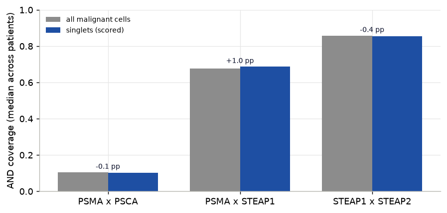

- **Positivity** is a per-cell raw count of at least 1 (single-cell detection, not a threshold on a pooled or averaged expression value); the threshold is swept for sensitivity (below).
- **Per-patient scoring (never pooled).** For markers A, B and each patient’s malignant cells, AND coverage is `P(A+ and B+ | malignant)` computed within that patient, then summarized across patients by the lower decile (Q0.10, the robustness floor) and the median. A patient with thousands of cells cannot dominate a pair’s score. Eighteen of the 24 patients clear the 20-cell floor and are scored, so per-patient summaries and the Q0.10 floor rest on n = 18, not 24.
- **Three references per pair.** (1) malignant coverage; (2) **matched benign prostate** from the same cohort, so a pair expressed across all prostate cells is penalised, not just one specific to the tumor;
  3. **healthy liability** as the worst-case co-positive fraction over Tabula Sapiens populations. The healthy side is assay-matched to the tumor (10x 3’ v3 only) and made **donor-robust**: within each tissue-by-cell-type population the fraction is computed per donor and summarized by the median across donors, keeping only populations with at least two donors, so no single donor or tiny population sets a worst case. Every worst-liability call carries its supporting donor and cell counts. Liabilities are reported both across all organs (the stricter statistic, retained in the tables) and **excluding the prostate** (normal-prostate expression may be clinically tolerable in selected advanced-disease contexts, whereas every other organ is dose-limiting); the figures use the extra-prostatic statistic.
- **Label-leakage control.** The cohort’s malignant label is built from the Liu and Wallace prostate-cancer expression signatures plus CopyKAT aneuploidy. HPN is a member of both signatures and EPCAM of the Liu signature, so any pair containing HPN or EPCAM is confounded: the gene helps define the label it then scores against. Such pairs are flagged, held off the Pareto frontier, and not nominated; the nominated PSMA x STEAP1 lead and the PSMA-PSCA control contain no signature gene. A full fix recomputes the labels with all 29 screened genes removed from the signatures (future work).
- **Gate algebra.** For each group a single matrix product over the float32 panel positivity matrix yields AND, NOT (`A+ and B-`) and OR counts for every pair at once; co-positive counts stay far below the float32 exact-integer limit, so there is no overflow, and NOT gates are directed (all 812 activator-blocker orientations are scored). These Boolean gates are screening abstractions of candidate receptor logic; they do not model antigen-density thresholds, residual single-arm activity, or the architecture-specific signalling of a balanced split-signal CAR, synNotch, or Tmod circuit.
- **Ranking.** Pairs are placed on a Pareto frontier of per-patient coverage floor (higher better) against worst extra-prostatic liability (lower better). Only surface-accessible markers are nominatable.
- **Reproducibility.** Every number below is read from a committed table in `results/tables/`; the report redraws its figures from those tables with no network or model call. The healthy pull uses the Census raw-count layer with `is_primary_data == True` (deduplicated cells), release `2025-01-30`, and confirms the panel features are present in the query (ACPP was the one panel gene absent).

# 4 Results

## 4.1 Single surface antigens each carry a large normal-tissue liability

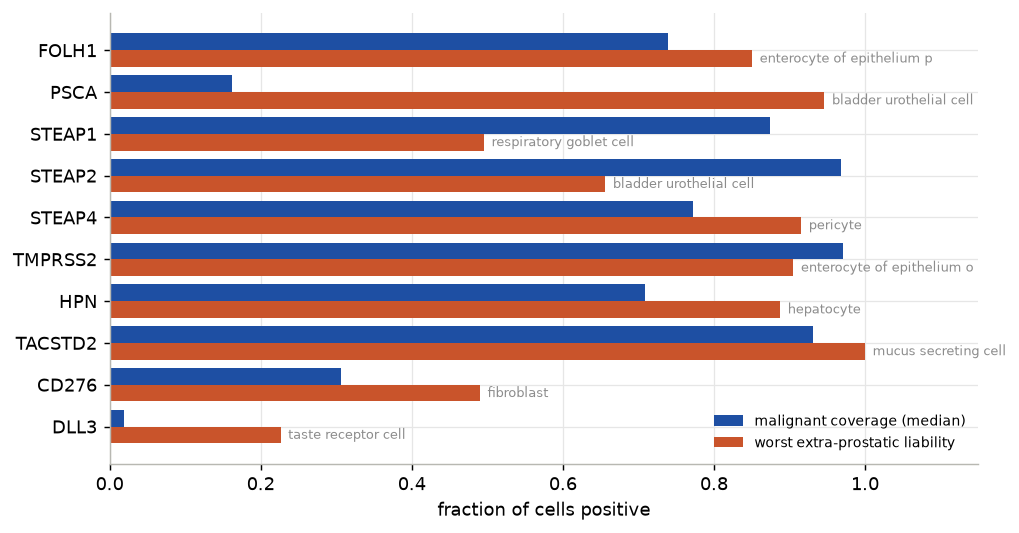

Figure 2: Single surface antigens: per-patient malignant coverage (median) against the worst-case extra-prostatic normal-tissue co-detection. Every strong single antigen also carries a large normal-tissue transcript liability; the recovered worst tissues are concordant with known biology (FOLH1/PSMA to duodenum, PSCA to bladder urothelium).

- Each strong single antigen is broadly positive on the tumor but also on at least one healthy cell type: the scan independently recovers PSMA’s duodenal and PSCA’s bladder-urothelial expression, a qualitative sanity check that the recovered tissues match known biology, not a claim that the fractions are quantitatively exact.

## 4.2 The AND gate recovers PSMA-PSCA and collapses its single-agent liabilities

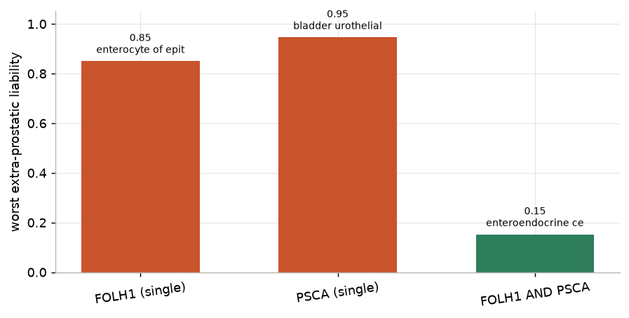

Figure 3: Positive control. PSMA (FOLH1) and PSCA are each broadly detected off the prostate (duodenum, bladder), but requiring both at once (AND) collapses the worst extra-prostatic co-detection roughly sixfold, recapitulating the direction of the preclinical rationale for the split-signal PSMA x PSCA CAR.

- **Recovered.** PSMA alone reaches **0.85** co-detection in duodenal enterocytes and PSCA alone **0.95** in bladder urothelium; the **PSMA and PSCA** gate drops the worst extra-prostatic co-detection to **0.15** (a reduction of 0.79), the expected direction of the preclinical benchmark.

- **Against a random baseline.** 57% of the sampled surface pairs (drawn from the same curated panel) score worse than PSMA-PSCA on extra-prostatic selectivity, defined as median malignant co-detection minus worst extra-prostatic liability. This is a weak signal: a pair can also look clean by carrying little tumor coverage, so it is a sanity check, not proof of specificity.

- Its low malignant co-detection (0.10 median) is consistent with limited PSCA transcript detection in this dataset; protein-level measurement would be needed to separate technical non-detection from biological heterogeneity. It motivates looking for higher-coverage pairs of comparable liability.

## 4.3 A Pareto frontier of surface pairs with higher coverage than PSMA-PSCA

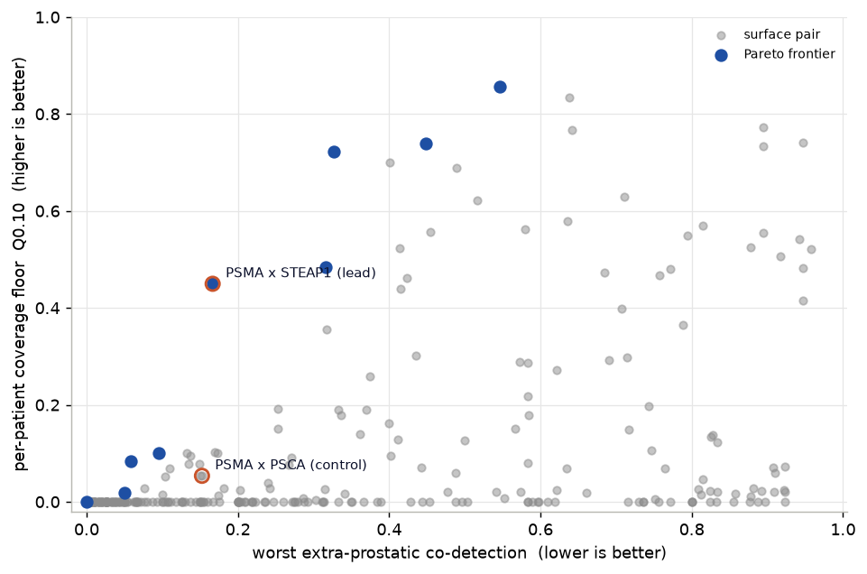

Figure 4: Surface-accessible AND pairs (label-leakage pairs excluded): per-patient coverage floor (Q0.10) against worst extra-prostatic co-detection. Upper-left is better. Frontier pairs are filled; the PSMA-PSCA control and the nominated PSMA x STEAP1 lead are labelled. Excluded as non-nominatable: secreted markers, intracellular prostein, and any pair containing a malignant-label signature gene (HPN, EPCAM).

One surface-accessible pair is nominated. It is clean of label leakage (neither marker is a malignant-label signature gene) and, once the leakage-confounded HPN pairs are removed, it is Pareto-non-dominated among the surface-accessible candidates on the coverage/liability point estimates.

- **PSMA x STEAP1 — nominated lead.** Both antigens have clinical-grade binders. Per-patient coverage floor **Q0.10 = 0.45**, median **0.69** (versus 0.10 for PSMA-PSCA; the pair covers far more of the tumor, but that ratio is inflated because PSCA is under-detected in this assay, so it is not a clean coverage comparison). Its worst extra-prostatic co-detection is **0.17** in mucus secreting cell (5 donors), versus 0.85 / 0.50 for the single antigens. Its worst liability over **all** organs is higher, **0.52** in luminal cell of prostate epithelium, excluded from the extra-prostatic figure only because the prostate is the target organ. Whether either residual is clinically acceptable cannot be judged from transcript data, and coverage 0.69 / floor 0.45 are not obviously adequate for monotherapy.

- **Higher in malignant than adjacent-benign prostate.** More co-detection in annotated malignant than in matched benign prostate epithelium: the difference of per-patient medians is 0.60, and the paired within-patient difference (Robustness) is positive in every scored patient.

- **Coverage does not generalize to advanced disease.** Replication in the independent HuPSA cohort shows the pair covers only a subset of AR+ adenocarcinoma cells and collapses in neuroendocrine, progenitor and double-negative states (see Replication), so this coverage does not extend to the advanced-disease population most cell therapies target.

- **The pair is not novel, and AND is not the only architecture.** A dual PSMA/STEAP1 antibody-drug conjugate (ABBV-969) is in phase 1 (AbbVie 2026), but as a single molecule binding either antigen it is OR-like, not a strict AND gate. Our contribution is the per-patient, benchmark-anchored AND framing, not the target pair.

- **HPN pairs are excluded as confounded.** STEAP1 x HPN and PSMA x HPN scored well, but HPN is a member of the Liu and Wallace signatures used to build the malignant-cell label, so their coverage is inflated by label leakage (see Methods); they are not nominated pending recomputation of the labels without the screened genes.

**Surface-accessible AND candidates** (top 15 of 276 clean targetable pairs; a further 49 pairs containing a malignant-label signature gene, HPN or EPCAM, are excluded as label-leakage confounded). Ranked by extra-prostatic selectivity: median malignant co-detection minus worst extra-prostatic co-detection. `*` marks the nominated lead; `frontier` marks Pareto-non-dominated pairs; `donors` supports the worst-liability population. Hypothesis-generating rankings over transcript co-detection, not validated targets.

| pair | Q0.10 | median | worst xp | worst cell type | donors | mal-ben | frontier |
| --- | --- | --- | --- | --- | --- | --- | --- |
| STEAP1 x STEAP2 | 0.72 | 0.85 | 0.33 | respiratory goblet cell | 4 | 0.6 | yes |
| PSMA x STEAP1 * | 0.45 | 0.69 | 0.17 | mucus secreting cell | 5 | 0.6 | yes |
| STEAP1 x TMPRSS2 | 0.7 | 0.84 | 0.4 | bladder urothelial cell | 6 | 0.6 |  |
| PSMA x STEAP2 | 0.48 | 0.73 | 0.32 | mucus secreting cell | 5 | 0.64 | yes |
| STEAP1 x CD46 | 0.74 | 0.85 | 0.45 | bladder urothelial cell | 6 | 0.52 | yes |
| STEAP2 x TMPRSS2 | 0.86 | 0.93 | 0.55 | bladder urothelial cell | 6 | 0.64 | yes |
| STEAP1 x TACSTD2 | 0.69 | 0.84 | 0.49 | respiratory goblet cell | 4 | 0.49 |  |
| STEAP1 x STEAP4 | 0.52 | 0.74 | 0.41 | respiratory goblet cell | 4 | 0.57 |  |
| PSMA x TACSTD2 | 0.44 | 0.71 | 0.41 | mucus secreting cell | 5 | 0.62 |  |
| STEAP1 x CDH1 | 0.56 | 0.74 | 0.45 | respiratory goblet cell | 4 | 0.5 |  |
| STEAP1 x TMEFF2 | 0.08 | 0.34 | 0.06 | epithelial cell | 2 | 0.33 | yes |
| STEAP2 x CD46 | 0.83 | 0.91 | 0.64 | bladder urothelial cell | 6 | 0.57 |  |
| PSMA x STEAP4 | 0.36 | 0.59 | 0.32 | mucus secreting cell | 5 | 0.52 |  |
| STEAP2 x TMEFF2 | 0.1 | 0.35 | 0.1 | retinal bipolar neuron | 3 | 0.34 | yes |
| STEAP2 x TACSTD2 | 0.77 | 0.9 | 0.64 | bladder urothelial cell | 6 | 0.54 |  |

## 4.4 Robustness: per patient and across positivity thresholds

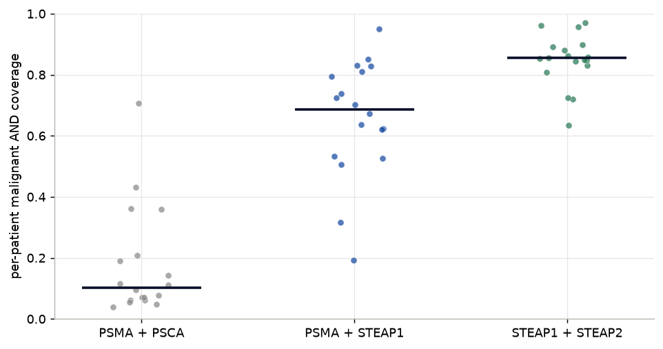

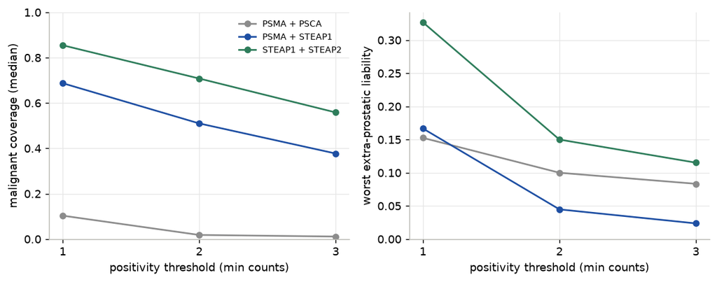

- Both candidates survive threshold tightening: malignant co-detection decreases gradually while the worst extra-prostatic co-detection falls, so the selectivity ranking is not an artifact of the loosest positivity call.

Highest extra-prostatic healthy populations for PSMA x STEAP1 (donor-robust AND co-detection, with donor and cell support):

| tissue | cell_type | coverage | n_donors | n_cells |
| --- | --- | --- | --- | --- |
| respiratory system | mucus secreting cell | 0.167 | 5 | 269 |
| small intestine | paneth cell of epithelium of small intestine | 0.143 | 5 | 1657 |
| tongue | salivary gland cell | 0.14 | 2 | 734 |
| small intestine | intestinal crypt stem cell of small intestine | 0.095 | 5 | 531 |
| lung | respiratory goblet cell | 0.071 | 4 | 978 |
| respiratory system | basal cell | 0.065 | 5 | 10003 |

**Uncertainty (bootstrap over patients; 18 patients, 2000 resamples).** Resampling the unit of replication, patients rather than cells, gives between-subject intervals for PSMA x STEAP1:

- Median coverage **0.69** (95% CI 0.58–0.79); the per-patient floor **Q0.10 = 0.45** is much less stable (95% CI 0.19–0.61), so the floor is indicative rather than precise. Coverage is at least 0.4 in 89% of patients.

- Holding every pair’s liability fixed at its point estimate, the pair stays non-dominated on the **coverage axis** in **99.6%** of patient resamples. This is a coverage-stability check only: it does not resample the liability axis, on which the lead sits closest to competitors, so it is not a full test of frontier robustness.

- Worst extra-prostatic liability (respiratory system | mucus secreting cell): donor median **0.17**, and the **maximum across its 5 donors is 0.37**. With only 5 donors a bootstrap cannot exceed the observed maximum, so this is the worst donor rather than a calibrated interval; it still shows a donor-to-donor spread the median hides.

- Malignant-minus-benign co-detection, paired within patient: median **0.54** (95% CI 0.48–0.60), positive in **100%** of 18 patients with both compartments, so the tumor enrichment is not a compositional average.

**De-leaked sensitivity (label leakage).** This tests only the removal of HPN and EPCAM, the two panel genes that sit in the signatures: FOLH1 and STEAP1 are not signature members, so dropping the 29 panel genes leaves the Liu/Wallace signatures almost unchanged (Spearman **0.99**) and the proxy is re-ranked by that near-identical, AR-co-regulated signature, so stable coverage is partly guaranteed by construction. A leakage-free proxy (CopyKAT-aneuploid cells top-ranked by the de-leaked signature, count-matched) recovers **82%** of the authors’ malignant cells, and PSMA x STEAP1 coverage on it is essentially unchanged (**0.63** vs 0.67); this arm is computed on the doublet-inclusive cells with a pooled mean, not the singlet, per-patient scoring used elsewhere. A genuinely label-independent arm (a purely CNV-defined compartment without signature re-ranking, on the singlets) is future work.

**Do the two markers escape on different healthy cells?** An AND gate only lowers liability if PSMA and STEAP1 are positive on different normal cells. At each marker’s worst single tissue the other is nearly absent, so the gate collapses it: PSMA’s liability (0.85 in small intestine) falls to 0.01 because STEAP1 is off there, and STEAP1’s (0.50 in lung) falls to 0.07 because PSMA is off there. But the two single liabilities are moderately correlated across populations (Spearman **0.51**), and the residual AND liability sits in secretory epithelium (mucus, paneth, salivary) where the markers partly co-escape (co-escape ratio = share of the limiting marker’s positive cells that are double-positive, up to ~0.9). The predicted selectivity gain (a co-detection reduction, not a safety measurement) is real at the extremes but partial where the two escapes overlap:

[output not shown]

## 4.5 NOT gates: a negative result

No NOT gate (activator on the tumor, blocker sparing a normal tissue) achieved both high malignant coverage and low predicted normal-tissue escape. The 10 best-ranked exploratory activator/blocker combinations still retain a large activator-positive / blocker-negative fraction in normal tissue (worst extra-prostatic co-detection shown, with donor support), so none is an attractive candidate; the blocker-negative call also depends on trusting scRNA dropout. This is reported as a negative result:

| activator | blocker | Q0.10 | median | worst xp | worst cell type | donors |
| --- | --- | --- | --- | --- | --- | --- |
| STEAP1 | SLC34A1 | 0.739 | 0.874 | 0.496 | respiratory goblet cell | 4 |
| STEAP1 | CDH16 | 0.739 | 0.874 | 0.496 | respiratory goblet cell | 4 |
| STEAP2 | MUC1 | 0.6 | 0.843 | 0.477 | fibroblast | 5 |
| STEAP1 | MUC1 | 0.543 | 0.732 | 0.411 | fibroblast | 5 |
| STEAP2 | SLC34A1 | 0.936 | 0.968 | 0.653 | bladder urothelial cell | 6 |
| STEAP2 | CDH16 | 0.936 | 0.968 | 0.656 | bladder urothelial cell | 6 |
| TMPRSS2 | CDH16 | 0.894 | 0.97 | 0.903 | enterocyte of epithelium of large intestine | 3 |
| TMPRSS2 | SLC34A1 | 0.894 | 0.97 | 0.905 | enterocyte of epithelium of large intestine | 3 |
| CD46 | SLC34A1 | 0.856 | 0.958 | 0.963 | bladder urothelial cell | 6 |
| CD46 | CDH16 | 0.856 | 0.958 | 0.965 | bladder urothelial cell | 6 |

# 5 Replication in an independent, advanced-disease cohort

We replicated the nominated pair in **HuPSA** (Cheng et al. 2024), an independent prostate-cancer meta-analysis of **368,831 cells** from **6 10x studies** spanning normal, localized, castration-resistant, metastatic (mCRPC) and neuroendocrine disease. Malignancy uses HuPSA’s own cell-state labels (AdPCa, NEPCa, KRT7, progenitor-like), independent of our Liu/Wallace + CopyKAT call, so this is also a label-independent check. Replication is on tumor coverage; the healthy-liability side stays with Tabula Sapiens.

- **What replicates is the direction, not the level.** Tumor-specificity holds: malignant-minus-benign-epithelial AND co-detection is **+0.15**, positive in **83%** of 12 paired samples. But absolute coverage does not: median per-patient coverage across HuPSA is **0.15** versus 0.69 in the discovery cohort, roughly half even in matched localized disease.

- **The robust signal is the neuroendocrine collapse.** AND co-detection falls to essentially **0.000** in the NEPC, KRT7 and progenitor-like states, established de-differentiation biology. Within AR+ adenocarcinoma coverage is uneven — **0.13–0.37** across subclusters, ~0.18 at the disease level — and even the AR-high subcluster sits near mCRPC levels, so coverage does not track AR activity per se.

- **The mCRPC number is not clean antigen loss.** The mCRPC AND coverage (0.05) cannot be separated from cross-cohort transcript attenuation and the fact that the mCRPC bucket aggregates neuroendocrine cells. PSMA and STEAP1 protein are clinically retained or upregulated in castration-resistant adenocarcinoma (the basis of PSMA radioligand therapy and the STEAP1 engager), so this transcript number should not be read as protein loss.

PSMA x STEAP1 AND co-detection by malignant cell state (HuPSA; **pooled across cells**, both chemistries — descriptive, not the per-patient median used elsewhere):

| malignant state | AND coverage (pooled) | n cells |
| --- | --- | --- |
| AdPCa_AR+_2 | 0.37 | 2638 |
| AdPCa_AR+_1 | 0.35 | 27051 |
| AdPCa_Proliferating | 0.17 | 460 |
| AdPCa_AR+_3 | 0.13 | 198 |
| AdPCa_ARlo | 0.07 | 5957 |
| AdPCa_ARhi | 0.06 | 3904 |
| NEPCa | 0 | 8081 |
| Progenitor_like | 0 | 5993 |
| KRT7 | 0 | 1937 |

# 6 Discussion

## 6.1 In the context of the literature

- **Single-cell logic-gated discovery is established prior art.** Pan-cancer single-cell pair scans (Kwon, Kang, et al. 2023), a breast-cancer AND/OR/NOT circuit search (Madan et al. 2025), and a single-cell AND / AND-NOT sarcoma scan with a co-expression error model (Testa et al. 2025) precede this work. The contribution here is the per-patient scoring, the matched benign-prostate control, the assay-matched donor-robust liability, and the PSMA-PSCA recovery gate, not the algorithm.
- **The nominated pair is already in the clinic.** A dual PSMA/STEAP1 antibody-drug conjugate (ABBV-969) is in phase 1 (AbbVie 2026), but as an OR-like agent that engages either antigen, not a strict AND gate; PSMA-PSCA is a preclinical benchmark (Kloss et al. 2013) and STEAP1 is clinically druggable via a CD3 engager (Kelly et al. 2024). The AND framing, not the target pair, is what is new.
- **The advanced-disease limit fits known biology.** The pair’s collapse in neuroendocrine and double-negative states in the independent cohort (Cheng et al. 2024) is consistent with androgen-receptor lineage antigens being lost under neuroendocrine transdifferentiation: STEAP1 and PSMA expression tracks AR status and is lost in AR-null tumors (Bhatia et al. 2023). The low mCRPC transcript signal, by contrast, coincides with cross-cohort attenuation, while PSMA and STEAP1 protein are clinically retained in castration-resistant adenocarcinoma (the basis of PSMA radioligand therapy and the STEAP1 engager).
- **The NOT-gate negative is expected for this search space.** An effective NOT-gate blocker is a normal-cell antigen lost in the tumor (for example an HLA allele deleted by loss of heterozygosity), not a tumor antigen; a curated tumor-antigen panel is the wrong polarity, and genotype-based NOT gates in prostate would serve only the minority of tumors carrying the relevant loss.
- **Where the field is ahead.** Higher-order circuits of up to five antigens (Madan et al. 2025), genome-scale surfaceome search, and protein-level or functional validation remain beyond a curated-panel transcript scan and are the natural next steps.

## 6.2 Limitations

- **Label leakage from the malignant annotation.** The discovery cohort defines malignant cells partly from prostate-cancer expression signatures (Liu, Wallace) that contain HPN and EPCAM. Pairs with those genes are excluded as confounded, and a de-leaked sensitivity (Robustness) shows the clean lead is not driven by those two genes. That check is limited: it removes only HPN/EPCAM, and because FOLH1/STEAP1 are not signature members it leaves the signature almost unchanged, so it does not rule out coverage inflation from AR co-regulation. A complete fix would recompute the annotation on a CNV-defined compartment without the screened genes.
- **Transcript co-detection is a selectivity surrogate, not therapeutic safety.** scRNA measures mRNA, not surface antigen density, extracellular epitope availability, binding affinity, shedding, internalization, the minimum antigen density for activation, or residual single-arm signalling. HPA localization supports membrane-localization plausibility but does not qualify targetability; same-cell surface co-expression needs CITE-seq, multiplex IHC, or dual-color flow to confirm.
- **Statistical uncertainty is quantified for the lead, not the whole table.** The nominated pair carries bootstrap-over-patient intervals for coverage and a paired malignant-benign delta. The frontier-stability probability resamples only the coverage axis (liabilities held fixed), so it is a coverage-stability check, not a joint test; and the worst-liability “upper bound” is really the maximum over five donors. A joint-axis bootstrap, an FDR / empirical null over the ~325 pairs, and a hierarchical beta-binomial model with the selection re-run inside each resample all remain future work, so the non-lead rankings and the frontier robustness are still point estimates.
- **Assay-matched but single-assay.** The healthy reference is restricted to 10x 3’ v3 to match the tumor, so Smart-seq2 and other-chemistry cells in Tabula Sapiens are excluded and a liability seen only on another platform would be missed. Dissociation also selectively loses fragile populations.
- **NOT-gate calls trust B-negatives**, which are dropout-sensitive, and none cleared the liability bar (a negative result).
- **Advanced disease.** The pair is nominated on localised hormone-naive cancer. Replication in HuPSA shows coverage is uneven within AR+ adenocarcinoma and collapses in neuroendocrine / double-negative states, so it does not address the population most cell therapies target.
- **Malignant labels are the authors’ CNV/signature calls**, adopted rather than re-derived here.
- **The PSMA-PSCA benchmark is preclinical.** It is a safety/selectivity benchmark, not a coverage benchmark; its low co-detection is consistent with limited PSCA transcript detection in this dataset.

# 7 Conclusion

This analysis is a per-patient, transcriptome-based prioritization of candidate combinatorial antigens in localized prostate cancer. The PSMA-PSCA benchmark shows the expected collapse in normal-tissue transcript co-detection relative to its single markers. A single clean pair is nominated, PSMA x STEAP1: higher malignant co-detection than the benchmark and, once the leakage-confounded HPN pairs are removed, Pareto-non-dominated among the surface-accessible candidates. The target pair is already in clinical development as an OR-like dual antibody-drug conjugate (ABBV-969), so the contribution is the AND framing, not the pair. This is a hypothesis-generating ranking, not evidence of therapeutic safety. Replication in an independent cohort (HuPSA) confirms the malignant-vs-benign direction but not the coverage level, and the pair collapses in neuroendocrine and double-negative disease; its coverage even within AR+ adenocarcinoma is uneven, and the low mCRPC transcript number should not be read as antigen loss, since PSMA and STEAP1 protein are clinically retained in that setting.

The next steps: extend the scan to additional independent cohorts, especially metastatic and neuroendocrine disease; integrate protein-level evidence, surface proteomics and tissue proteogenomics (CPTAC) alongside same-cell CITE-seq and multiplex IHC, to move from transcript co-detection toward protein-confirmed, safety-informed targets; and recompute the malignant labels on a leakage-free CNV compartment. Until then, this is a hypothesis, not a validated target.

# 8 Reproducibility

The pipeline runs from a clean clone with `uv`; every table in `results/tables/` is regenerated by the numbered scripts in `scripts/`, and this report redraws its figures from those tables. See the README for the exact command sequence. The one exception is Supplementary Figure S1, a Claude Science workbench artifact (not regenerated by the pipeline).

# 9 Supplementary

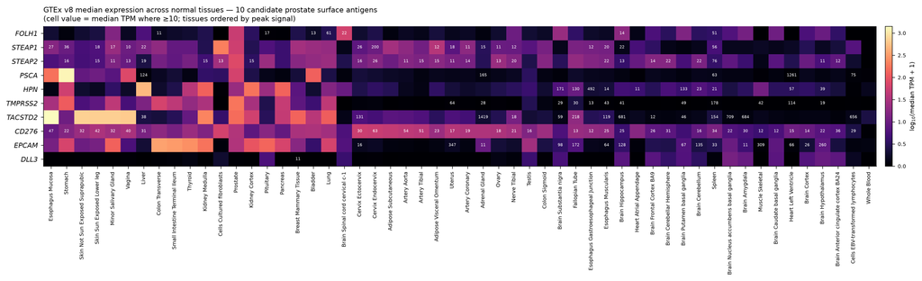

Figure 7: **Figure S1. Normal-tissue transcript expression of the panel antigens (GTEx).** Median TPM of the 10 candidate surface antigens across 54 GTEx v8 normal tissues (log-scaled; a cell is annotated where the median is at least 10 TPM, tissues ordered by peak signal). This is single-marker expression and does not speak to the AND gate; it corroborates the single-cell single-marker liabilities from an independent bulk dataset (PSMA in prostate, kidney, duodenum and brain; PSCA in stomach and bladder; hepsin in liver, kidney and pancreas). Generated in the Claude Science workbench from the GTEx and Human Protein Atlas connectors; a workbench artifact, not pipeline output.

# 10 References

AbbVie. 2026. “ABBV-969, a Dual PSMA- and STEAP1-Targeted Antibody-Drug Conjugate, in Metastatic Castration-Resistant Prostate Cancer: A Phase 1 First-in-Human Study.” https://doi.org/10.1200/JCO.2026.44.16_suppl.5014.

Apostolov, Eva, Daniel L Roden, Holly Holliday, Aurélie Cazet, Kate Harvey, Hanyun Zhang, Sunny Z Wu, et al. 2026. “Single-Cell and Spatial Transcriptomic Profiling Reveals Epithelial Functional States and Fibroblast Phenotypes in Hormone Therapy–Naïve Localized Prostate Cancer.” *Cancer Research* 86 (8): 1836–53. https://doi.org/10.1158/0008-5472.CAN-25-1202.

Bhatia, Vipul, Nikhil V Kamat, Tiffany E Pariva, Li-Ting Wu, et al. 2023. “Targeting Advanced Prostate Cancer with STEAP1 Chimeric Antigen Receptor T Cell and Tumor-Localized IL-12 Immunotherapy.” *Nature Communications* 14: 2041. https://doi.org/10.1038/s41467-023-37874-2.

Cheng, Siyuan, Lin Li, Yunshin Yeh, Yingli Shi, Omar Franco, Eva Corey, and Xin Yu. 2024. “Unveiling Novel Double-Negative Prostate Cancer Subtypes Through Single-Cell RNA Sequencing Analysis.” *Npj Precision Oncology* 8 (171). https://doi.org/10.1038/s41698-024-00667-x.

Cho, Jang Hwan, James J Collins, and Wilson W Wong. 2018. “Universal Chimeric Antigen Receptors for Multiplexed and Logical Control of t Cell Responses.” *Cell* 173 (6): 1426–38. https://doi.org/10.1016/j.cell.2018.03.038.

Kelly, William K, Daniel C Danila, Chia-Chi Lin, et al. 2024. “Xaluritamig, a STEAP1 x CD3 XmAb 2+1 Immune Therapy for Metastatic Castration-Resistant Prostate Cancer: Results from Dose Exploration in a First-in-Human Study.” *Cancer Discovery* 14 (1): 76–89. https://doi.org/10.1158/2159-8290.CD-23-0964.

Kloss, Christopher C, Maud Condomines, Marc Cartellieri, Michael Bachmann, and Michel Sadelain. 2013. “Combinatorial Antigen Recognition with Balanced Signaling Promotes Selective Tumor Eradication by Engineered t Cells.” *Nature Biotechnology* 31 (1): 71–75. https://doi.org/10.1038/nbt.2459.

Kwon, Joonha, Jaebeom Kang, et al. 2023. “Single-Cell Mapping of Combinatorial Target Antigens for CAR Switches Using Logic Gates.” *Nature Biotechnology* 41: 1593–1605. https://doi.org/10.1038/s41587-023-01686-y.

Madan, Sanna, Tian-Gen Chang, Eytan Ruppin, et al. 2025. “Single-Cell-Guided Identification of Logic-Gated Antigen Combinations for Designing Effective and Safe CAR Therapy.” *bioRxiv*. https://doi.org/10.1101/2025.03.19.644074.

Roybal, Kole T, Levi J Rupp, Leonardo Morsut, et al. 2016. “Precision Tumor Recognition by t Cells with Combinatorial Antigen-Sensing Circuits.” *Cell* 164 (4): 770–79. https://doi.org/10.1016/j.cell.2016.01.011.

Testa, Stefano, Aastha Pal, Ajay Subramanian, Sushama Varma, Jack Pengfei Tang, Danielle Graham, Sara Arfan, et al. 2025. “SCAN-ACT: Adoptive T Cell Therapy Target Discovery Through Single-Cell Transcriptomics.” *Genome Medicine* 17 (89). https://doi.org/10.1186/s13073-025-01514-9.

The Tabula Sapiens Consortium. 2022. “The Tabula Sapiens: A Multiple-Organ, Single-Cell Transcriptomic Atlas of Humans.” *Science* 376 (6594): eabl4896. https://doi.org/10.1126/science.abl4896.

The Tabula Sapiens Consortium, and Stephen R Quake. 2024. “Tabula Sapiens Reveals Transcription Factor Expression, Senescence Effects, and Sex-Specific Features in Cell Types from 28 Human Organs and Tissues.” *bioRxiv*. https://doi.org/10.1101/2024.12.03.626516.

Uhlén, Mathias, Linn Fagerberg, Björn M Hallström, et al. 2015. “Tissue-Based Map of the Human Proteome.” *Science* 347 (6220): 1260419. https://doi.org/10.1126/science.1260419.